# Module2_3_SickFish

Keaton Wilson, EKB

## Scenario

Here is our current scenario.

**What we know**: We found a correlation between eating fish and people getting sick, but that isn’t really the root of the problem. We have also found that a number of tanks are below the average temperature that might cause issues with fish immune systems.

**What we don’t know**: We don’t actually know if rates of disease are present above average levels in the tanks, and we definitely don’t know what kinds of factors are contributing to this problem (if there is one!).

Our first challenge is that we can’t sample the disease rate in all tanks. It’s too expensive and takes too long. Instead of sampling all 1000 tanks, we’ve tasked our aquaculture scientists to take a sub-sample (50 tanks). Our aquaculture scientists have shared this data with us.

Let’s scope it out:

```r
library(tidyverse)
sick_fish <- read_csv("../data/fish_sick_data.csv")
head(sick_fish)
```

```
## # A tibble: 6 × 8
##   tank_id species avg_daily_temp num_fish day_length tank_volume num_s…¹ size_…²
##     <dbl> <chr>            <dbl>    <dbl>      <dbl>       <dbl>   <dbl>   <dbl>
## 1     388 tilapia           24.3       93         10        399.       3   2789.
## 2     425 tilapia           24.6       98         11        400.       4   2787.
## 3     420 tilapia           23.0      103          9        399.      10   2792.
## 4     819 trout             14.1       85         11        401.       7    151.
## 5     176 tilapia           23.3       98         10        400.       3   2785.
## 6     926 trout             15.4       79         12        400.       3    149.
## # … with abbreviated variable names ¹num_sick, ²size_day_30
```

Oh no, we might need to add a Fahrenheit column…let’s practice.

```r
c_to_f <- function(c = NULL){
  f <- (c * (9/5)) + 32
  return(f)
}

sick_fish <- sick_fish %>%
  mutate(avg_daily_tempF = c_to_f(avg_daily_temp))
```

## Data Exploration

One of the best ways to get an idea of what our data look like and are telling us is by calculating some summary statistics.

### Group Challenge

Let’s use the `tidyverse` to calculate some summary statistics for the data we have been given.

Write some code that produces the following values *per species*.

- mean (average) number of sick fish
- mean (average) percentage of sick fish per tank
- how many tanks

```r
sick_fish %>%
  group_by(species) %>%
  summarize(mean_sick = mean(num_sick),
            mean_perc = mean(num_sick/num_fish),
            n = n()) # counts
```

```
## # A tibble: 2 × 4
##   species mean_sick mean_perc     n
##   <chr>       <dbl>     <dbl> <int>
## 1 tilapia      4.97    0.0492    31
## 2 trout        7.74    0.101     19
```

Summary statistics (such as means) are helpful for giving us some ideas about our data, but they don’t tell us the full story. Plotting data can give us some additional insights.

Before we plot, let’s create two different data frames: one for tilapia and one for trout.

```r
sick_tilapia <- sick_fish %>%
  filter(species == "tilapia")
sick_trout <- sick_fish %>%
  filter(species == "trout")
```

Now, let’s plot our data to get an idea of the distribution (spread) of the data. We can make histograms to see if there are some tanks that have a lot of sick fish and are increasing this average or if most of the tanks seem to have about the same number of sick fish.

What would these two different scenarios tell us?

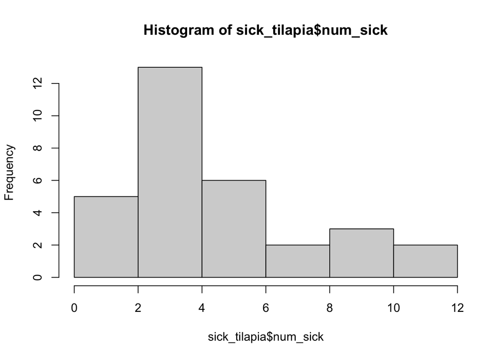

```r
hist(sick_tilapia$num_sick)
```

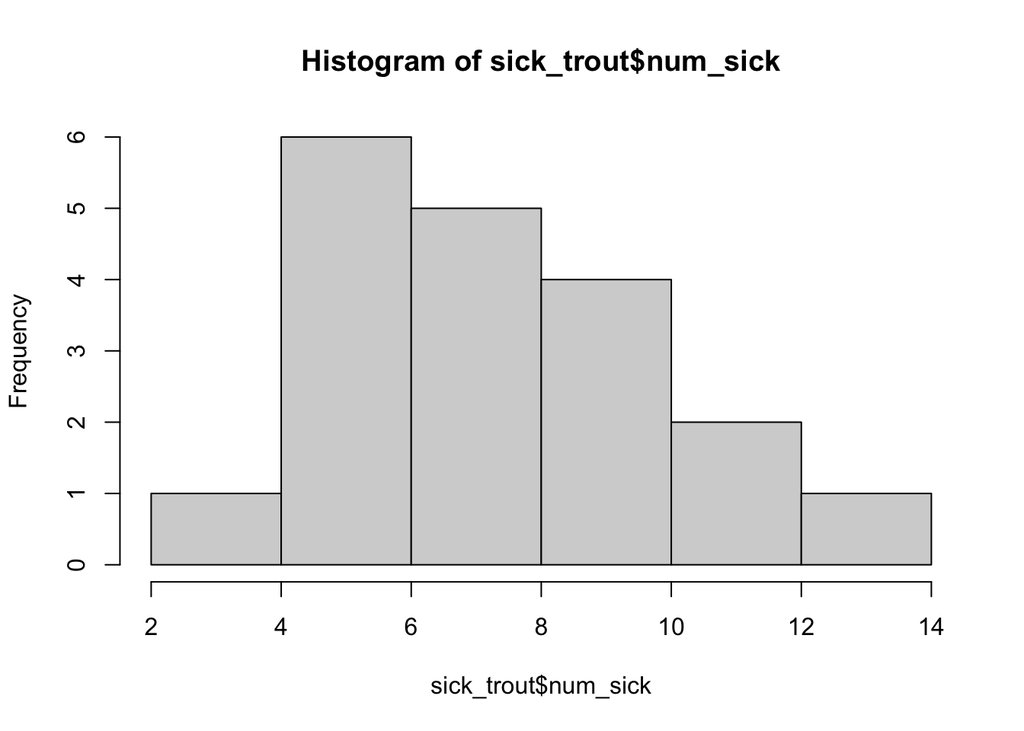

```r
hist(sick_trout$num_sick)
```

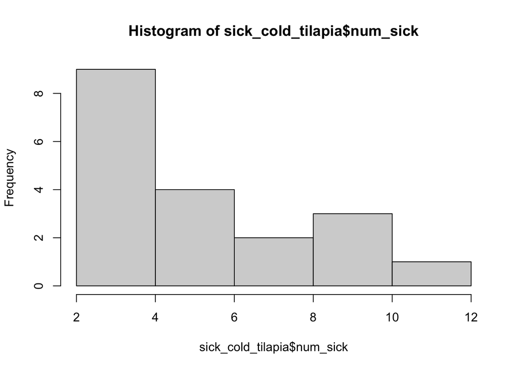

```r
sick_cold_tilapia <- sick_tilapia %>%
  filter(avg_daily_tempF < 75)
sick_cold_trout <- sick_trout %>%
  filter(avg_daily_tempF < 59)

hist(sick_cold_tilapia$num_sick)
```

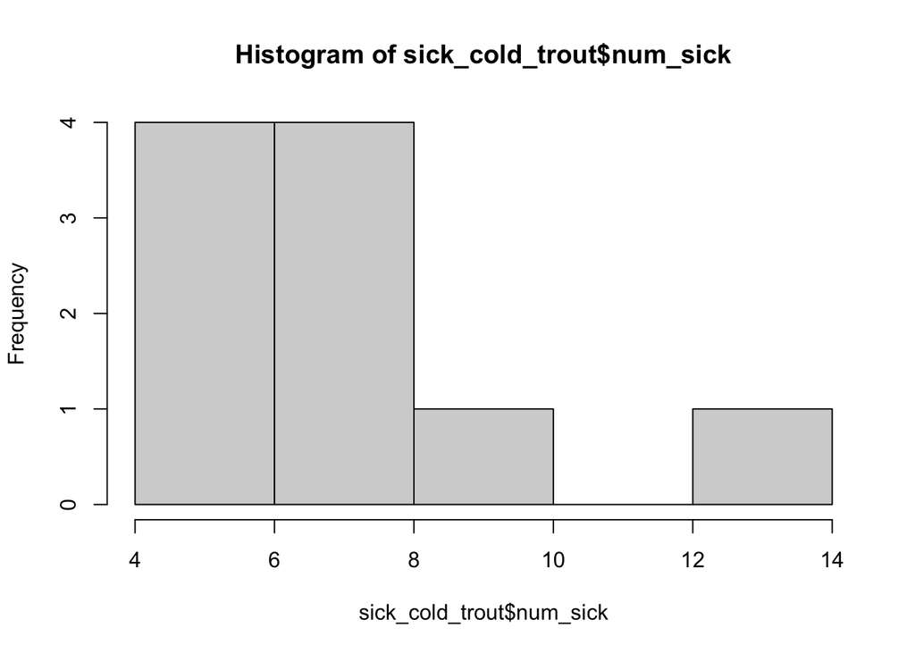

```r
hist(sick_cold_trout$num_sick)
```